# Modèle de probabilité de transmission : distance 2m

Manal NHILI

# 1 Import libraries

```r
# Reporting
library(knitr) # R code chunking in documents
library(rmarkdown) # Dynamic report generation

# Visualization
library(ggplot2) # Graphing/visualization
library(DT) # Interactive HTML tables
library(gt) # Nicely formatted plain tables
library(httpgd) # HTTP graphics device

# Bayesian Modeling & MCMC
library(nimble) # Building MCMC models
library(coda) # MCMC diagnostics
library(bayesplot) # MCMC diagnostics
library(postpack) # Post-processing MCMC draws
library(loo) # Leave-one-out cross validation
library(mcmcplots) # MCMC traceplots

# Model Evaluation
library(Metrics) # Model evaluation metrics
library(ROCR) # Model performance visualization
library(caret) # Machine learning model evaluation

# Data Wrangling
library(tidyr) # Data tidying
library(dplyr) # Data manipulation
library(readxl) # Excel data I/O
```

# 2 Import data

```r
sero <- read_excel("D:/segmented_model/model_2m/data_seg_2m.xlsx")
datatable(sero)
```

|  | experiment | duration | Cap1 | Cap2 | time | infected |
| --- | --- | --- | --- | --- | --- | --- |
| 1 | 1 | 1 | 436 | 100 | 36.87 | 0 |
| 2 | 1 | 1 | 436 | 116 | 48.7 | 0 |
| 3 | 1 | 1 | 436 | 255 | 54.3 | 0 |
| 4 | 1 | 1 | 436 | 449 | 53.68 | 0 |
| 5 | 1 | 1 | 436 | 3008 | 10.92 | 0 |
| 6 | 1 | 1 | 436 | 3310 | 48.18 | 0 |
| 7 | 1 | 6 | 436 | 100 | 158.18 | 0 |
| 8 | 1 | 6 | 436 | 116 | 173.52 | 0 |
| 9 | 1 | 6 | 436 | 255 | 217.65 | 0 |
| 10 | 1 | 6 | 436 | 449 | 160.07 | 0 |

[output cut: 56 more lines]

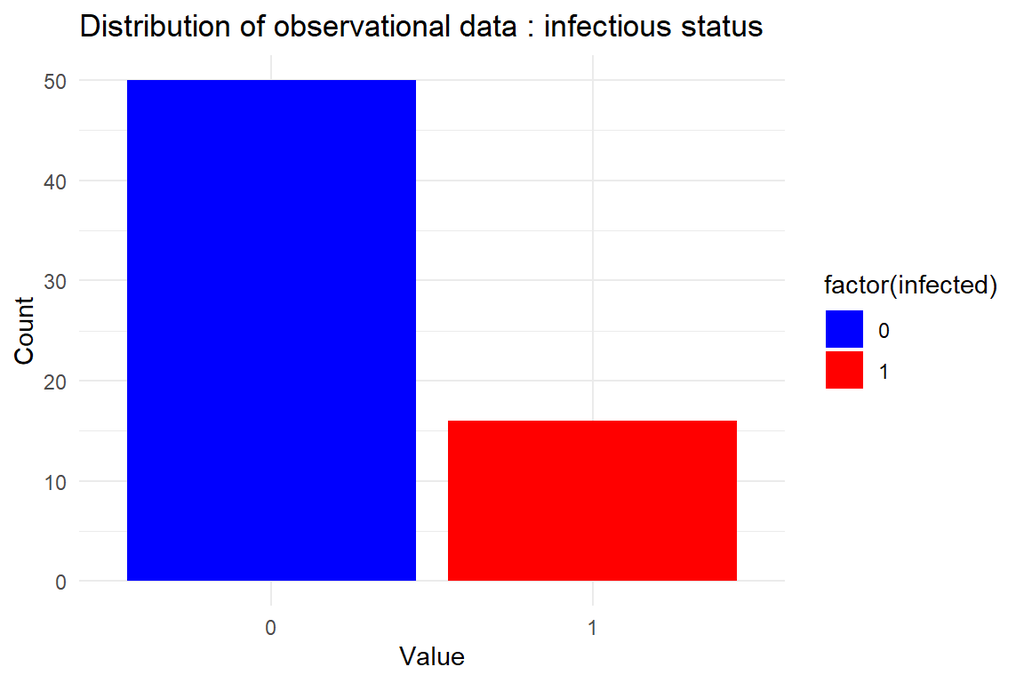

```r
ggplot(sero, aes(x = factor(infected))) +
  geom_bar(aes(fill = factor(infected)), position = "dodge") +
  labs(title = "Distribution of observational data : infectious status", x = "Value", y = "Count") +
  scale_fill_manual(values = c("0" = "blue", "1" = "red")) +
  theme_minimal()
```

# 3 Model

## 3.1 Define Nimble code

```r
y <- sero$infected
t<-sero$time

data = list(y=y, t=t)
```

```r
code <- nimbleCode({

  # Priors
  p ~ dunif(0.0005, 0.01)

  # Boucle sur les observations
  for (i in 1:nrow(sero)) {

    p_ind[i] <- 1- (1 - p)^t[i]

    y[i] ~ dbern(p_ind[i])

  }

})
```

## 3.2 Define initial values per chains

```r
# Valeurs initiales
inits = lapply(1:5, function(i){

  list(
    p = runif(1, 0.0005, 0.01)
  )

})
```

## 3.3 Hyperparameters tuning

Tuning hyperparameters of the model by defining a grid of values and fitting the model for each combination of hyperparameters and keeping the one that gives the lowest WAIC.

```r
# Define parameter grids to search over
niter_grid = c(10000, 50000, 100000)
thin_grid = c(1, 5, 10)
burnin_grid = c(100, 500, 1000, 5000)

# Function to fit model and compute WAIC
fit_and_compare <- function(niter, thin, burnin) {

  # Fit model using MCMC
  ppr_mcmc <- nimbleMCMC(code = code,
                      data = data,
                      inits = inits,
                      thin = thin,
                      niter = niter,
                      nburnin = burnin,
                      nchains = 5,
                      monitors = list("p"),
                      setSeed = 123,
                      progressBar = TRUE,
                      samples = TRUE,
                      summary = TRUE,
                      WAIC = TRUE)

  # Compute WAIC
  waic <- ppr_mcmc$WAIC$WAIC

  # Return WAIC
  return(waic)
}
```

```r
# Vecteur pour stocker tous les WAIC
waics <- numeric(length(niter_grid)*length(thin_grid)*length(burnin_grid))

# Compteur pour index dans waics
count <- 1

# Tester toutes les combinaisons
for(niter in niter_grid) {
  for(thin in thin_grid) {
    for(burnin in burnin_grid) {

        waic <- fit_and_compare(niter, thin, burnin)

        # Stocker ce WAIC
        waics[count] <- waic
        count <- count + 1
      }
    }
  }
```

## 3.4 Getting the best combination of hyperparameters

```r
# Trouver l'index du meilleur WAIC
best <- which.min(waics)

# Extraire les meilleurs paramètres
iter_index <- ((best - 1) %/% (length(thin_grid) * length(burnin_grid))) + 1
thin_index <- ((best - 1) %/% length(burnin_grid)) %% length(thin_grid) + 1
burnin_index <- ((best - 1) %% length(burnin_grid)) + 1

best_niter <- niter_grid[iter_index]
best_thin <- thin_grid[thin_index]
best_burnin <- burnin_grid[burnin_index]


# Afficher de façon formatée
cat("Best Hyperparameters :", "\n")
cat(paste0("Niter : ", best_niter, "\n"))
cat(paste0("Thin : ", best_thin, "\n"))
cat(paste0("Burnin : ", best_burnin, "\n"))
```

[output not shown]

## 3.5 Fitting model with best combination of hyperparameters

```r
ppr_mcmc <- nimbleMCMC(code = code,
                      data = data,
                      inits = inits,
                      thin = best_thin,
                      nburnin = best_burnin,
                      monitors = list("p", "p_ind"),
                      niter = best_niter,
                      nchains = 5,
                      setSeed = 123,
                      progressBar = TRUE,
                      samples = TRUE,
                      summary = TRUE,
                      WAIC = TRUE)
```

```r
#save(ppr_mcmc, inits, file = "p_samples_2m.RData")
```

```r
load("p_samples_2m.RData")
```

```r
theta_inits <- as.data.frame(inits)

new_names = paste0("chain_", 1:5)

# Change colnames
colnames(theta_inits) = new_names[1:5]

gt(theta_inits) %>%
  tab_header(title = "initial values for MCMC chains")
```

initial values for MCMC chains

| chain_1 | chain_2 | chain_3 | chain_4 | chain_5 |
| --- | --- | --- | --- | --- |
| 0.001648912 | 0.007641224 | 0.002041666 | 0.00518347 | 0.009641187 |

```r
waic <- ppr_mcmc$WAIC$WAIC
cat(waic)
```

```
## 68.30118
```

```r
codaSamples <- post_convert(ppr_mcmc$samples)
p <- codaSamples[, "p"]
```

# 4 Visualization:

We plot the density of the posterior and the trace plot of the chains.

## 4.1 Density plot

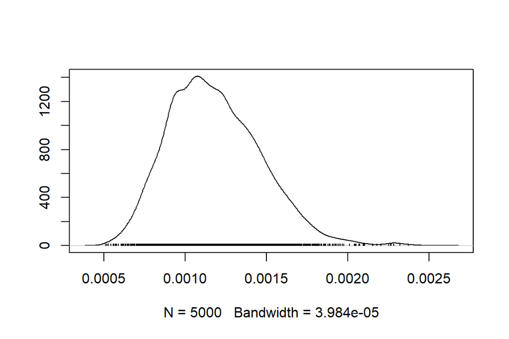

```r
densplot(p)
```

## 4.2 Trace plot

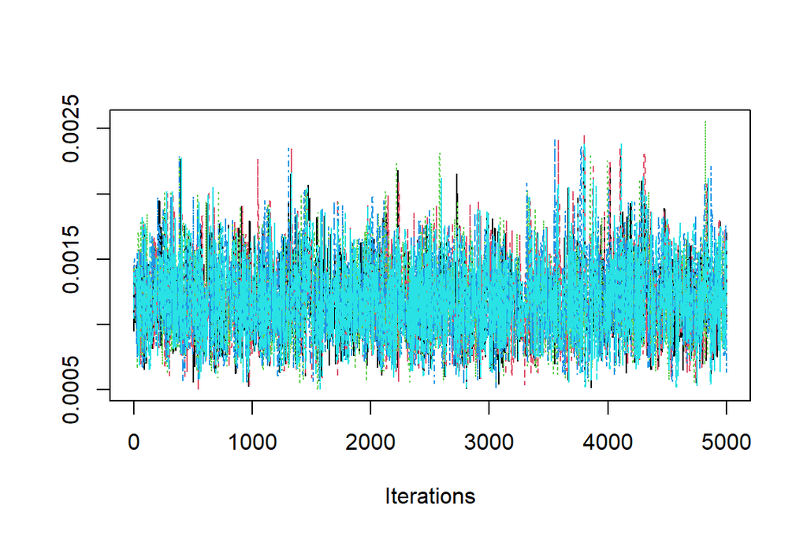

```r
traceplot(p)
```

# 5 Assessing model fit quality using WAIC

```r
waic <- ppr_mcmc$WAIC
waic
```

```
## nimbleList object of type waicNimbleList
## Field "WAIC":
## [1] 68.30118
## Field "lppd":
## [1] -33.08966
## Field "pWAIC":
## [1] 1.060924
```

# 6 Summary Statistics

```r
summary(p)
```

```
##
## Iterations = 1:5000
## Thinning interval = 1
## Number of chains = 5
## Sample size per chain = 5000
##
## 1. Empirical mean and standard deviation for each variable,
##    plus standard error of the mean:
##
##           Mean             SD       Naive SE Time-series SE
##      1.183e-03      2.848e-04      1.801e-06      3.836e-06
##
## 2. Quantiles for each variable:
##
##      2.5%       25%       50%       75%     97.5%
## 0.0007073 0.0009712 0.0011566 0.0013672 0.0017843
```

```r
loo_result <- loo(as.matrix(p))
print(loo_result)
```

```
##
## Computed from 25000 by 1 log-likelihood matrix
##
##          Estimate SE
## elpd_loo      0.0 NA
## p_loo         0.0 NA
## looic         0.0 NA
## ------
## Monte Carlo SE of elpd_loo is 0.0.
##
## All Pareto k estimates are good (k < 0.5).
## See help('pareto-k-diagnostic') for details.
```

```r
loo_result$diagnostics
```

```
## $pareto_k
## [1] -0.3244924
##
## $n_eff
## [1] 25000
```

# 7 Convergence Diagnostics

## 7.1 Gelman-Rubin diagnostic

The Potential Scale Reduction Factor (PSRF), also known as the **Gelman-Rubin diagnostic** $(\hat{R})$, is a widely used metric for assessing the convergence of Markov Chain Monte Carlo (MCMC) chains in Bayesian analysis. A PSRF equal to 1 is indicative of well-converged chains. The diagnostic compares the variability within each chain to the variability between chains. A value of 1 suggests that the chains have reached a common distribution and have effectively explored the parameter space. In our analysis, the PSRF being equal to 1 provides confidence in the convergence of the MCMC chains, indicating that the chains have reached a stable and consistent estimate of the target distribution.

```r
gelman.diag(p)
```

```
## Potential scale reduction factors:
##
##      Point est. Upper C.I.
## [1,]          1          1
```

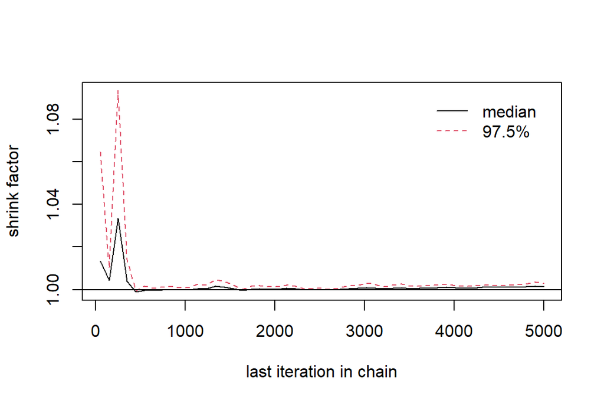

```r
gelman.plot(p)
```

## 7.2 Geweke’s convergence diagnostic

The **Geweke’s convergence diagnostic** was applied to assess the convergence of multiple MCMC chains. The diagnostic involves dividing each chain into two windows (typically the first 10% and the last 50% of iterations) and comparing the means of these segments using a z-score. A small z-score and comparable fractions in the two windows indicate convergence.

```r
geweke.diag(p)
```

```
## $chain1
##
## Fraction in 1st window = 0.1
## Fraction in 2nd window = 0.5
##
##   var1
## 0.9297
##
##
## $chain2
##
## Fraction in 1st window = 0.1
## Fraction in 2nd window = 0.5
##
##   var1
## 0.9059
##
##
## $chain3
##
## Fraction in 1st window = 0.1
## Fraction in 2nd window = 0.5
##
##  var1
## 1.493
##
##
## $chain4
##
## Fraction in 1st window = 0.1
## Fraction in 2nd window = 0.5
##
##   var1
## 0.5194
##
##
## $chain5
##
## Fraction in 1st window = 0.1
## Fraction in 2nd window = 0.5
##
##    var1
## -0.2071
```

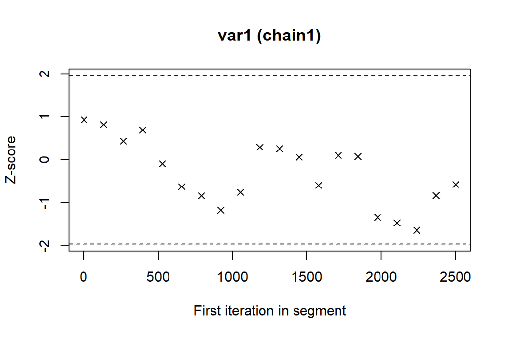

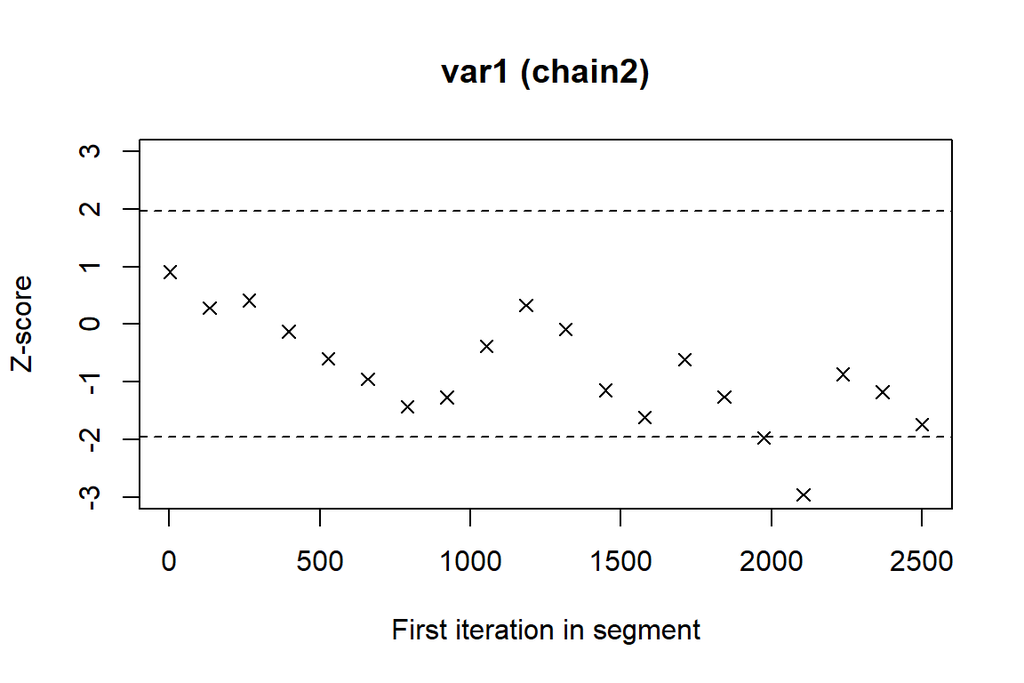

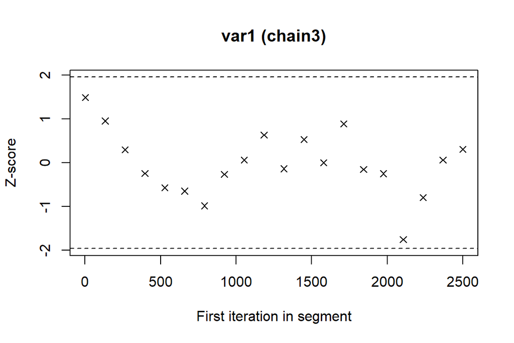

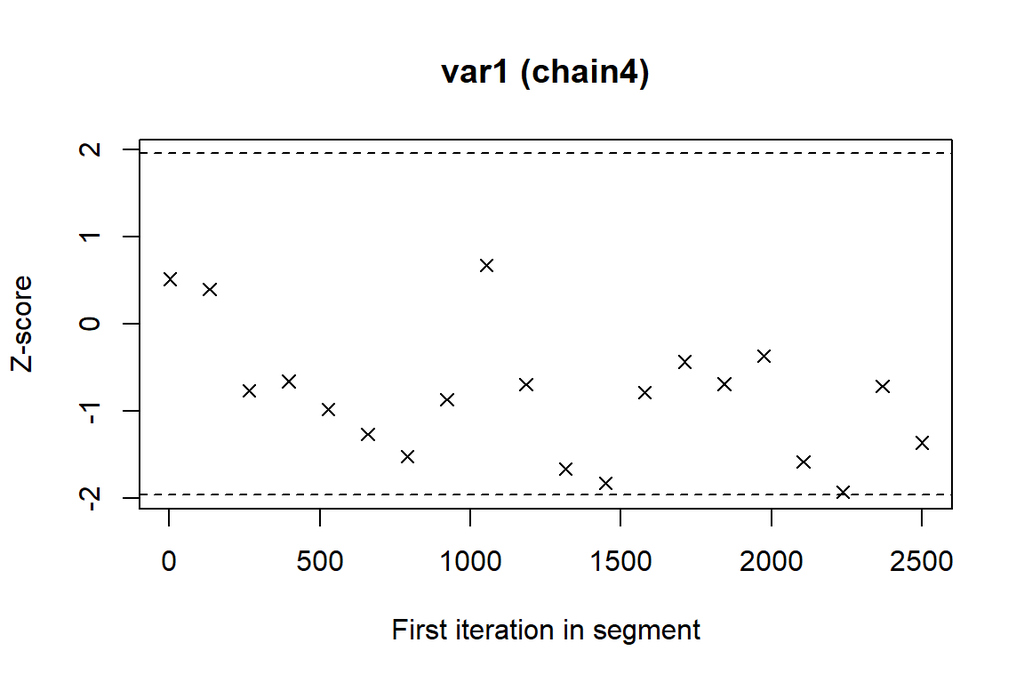

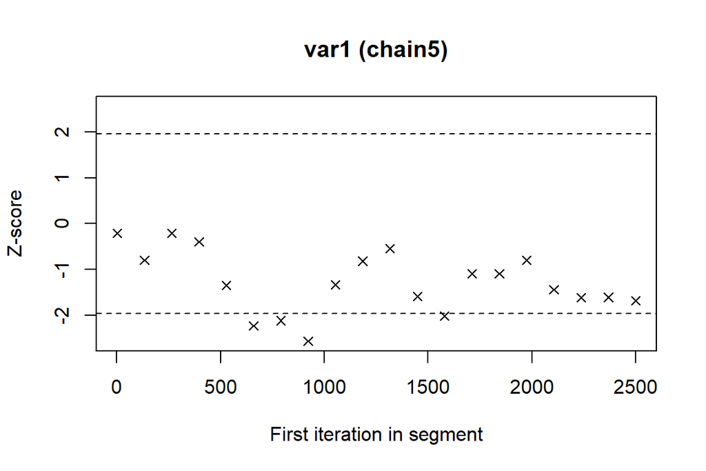

```r
geweke.plot(p)
```

# 8 Plot autocorrelation plots for all chains

Autocorrelation plots were generated to assess the correlation between successive observations in each Markov Chain Monte Carlo (MCMC) chain. The plots below illustrate the autocorrelation function (ACF) for the parameter $p$ in each chain.

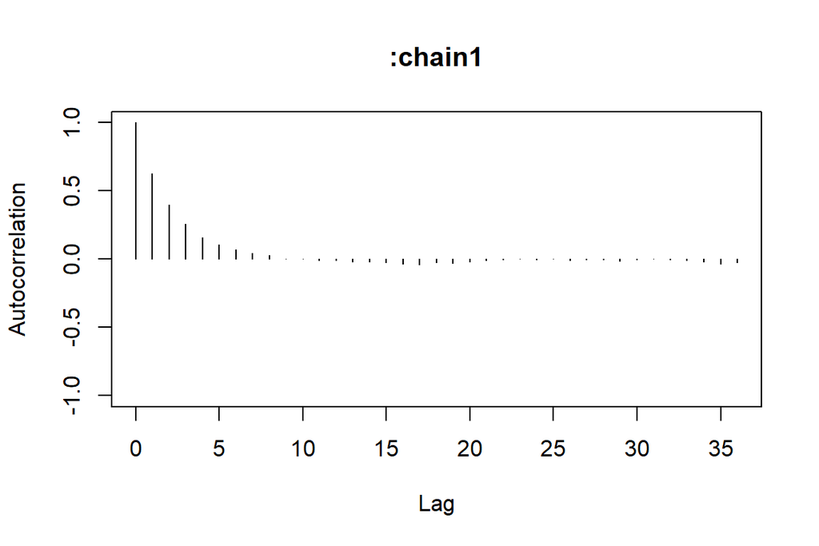

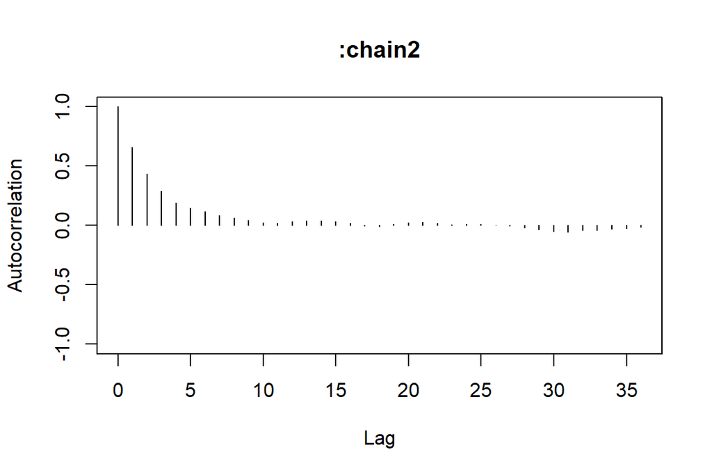

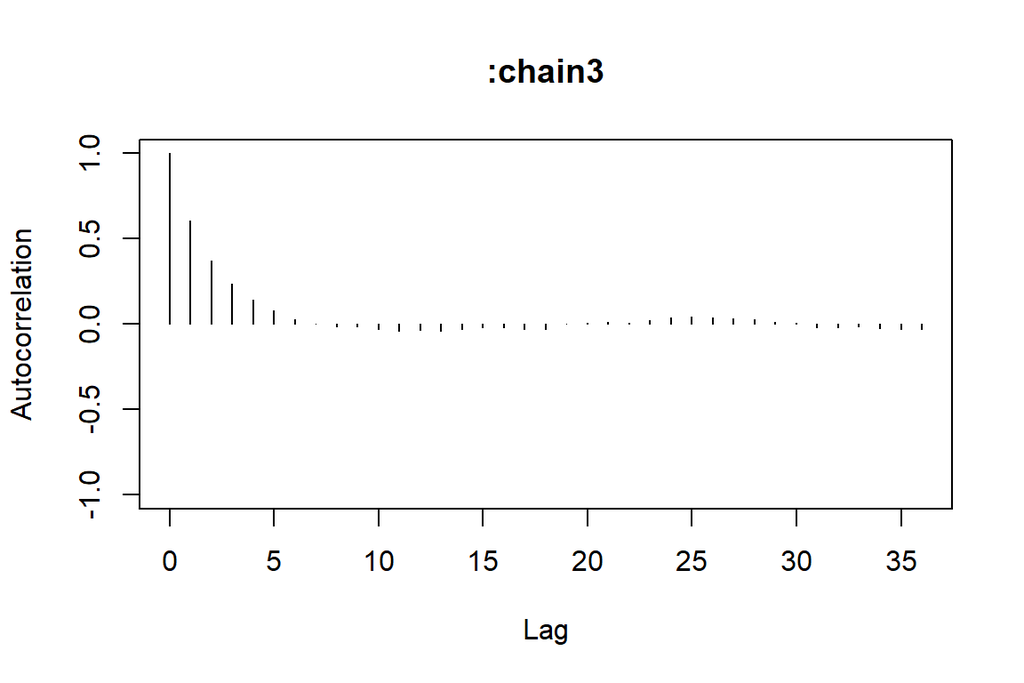

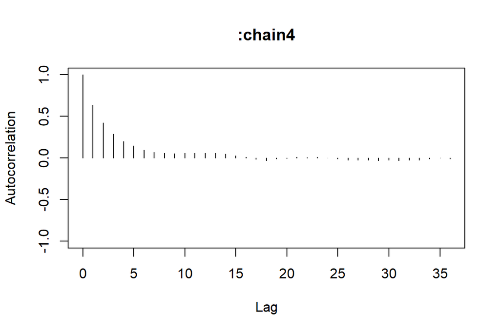

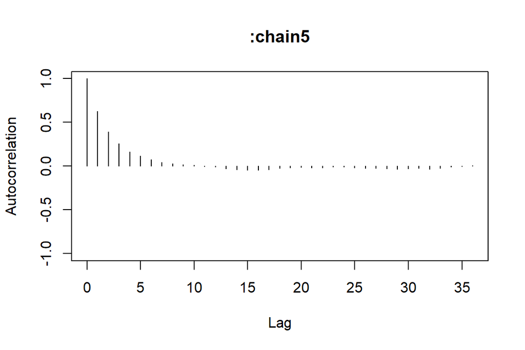

```r
autocorr.plot(p)
```

# 9 Effective sample size

The **effective sample size (ESS)** is a metric used in the context of Markov Chain Monte Carlo (MCMC) sampling to quantify the amount of information or independence captured by the samples. It provides an estimate of how many independent samples in the Markov chain are equivalent to the autocorrelated samples obtained.

$$ESS = \frac{n}{1 + 2\sum_{t=1}^{T} \rho_t}$$
In this formula:

- $ESS$ is the effective sample size.
- $n$ is the total number of samples.
- $ρ_t$ is the autocorrelation at lag $t$.
- $T$ is the maximum lag considered in the autocorrelation calculation.

An ESS of 5548.339 suggests good mixing and provides a reasonable estimate of the effective information content in our MCMC samples for the variable **`p`**.

```r
cat(effectiveSize(p))
```

```
## 5548.339
```

# 10 Posterior predictive check

```r
p_samples <- sample(as.matrix(p), 1000)
```

```r
n_ind <- nrow(sero)
n_iter <- length(p_samples)

p_ind_samples <- matrix(NA, nrow = n_ind, ncol = n_iter)
aucs <- numeric(n_iter)

sens <- numeric(n_iter)


for(j in 1:n_iter){

  p_j <- p_samples[j]

  p_ind_j <- numeric(n_ind)

  for(i in 1:n_ind){

    t_i = sero$time[i]
    p_ind_j[i] <- 1 - (1 - p_j)^t_i

  }
  p_ind_samples[,j] <- p_ind_j

  prediction <- prediction(p_ind_j, sero$infected)

  auc <- performance(prediction, "auc")@y.values[[1]]
  sensi <- performance(prediction, "sens")@y.values[[1]]


  aucs[j] <- auc

  sens[j] <- sensi

}
```

```r
p_means = apply(p_ind_samples, 1, mean)
```

```r
sd_p <- apply(p_ind_samples, 1, sd)
```

```r
Q2.5 <- apply(p_ind_samples, 1, quantile, probs = 0.025)
Q97.5 <- apply(p_ind_samples, 1, quantile, probs = 0.975)
```

```r
summary_df <- data.frame(Captor = sero$Cap2,
                         Obs = sero$infected,
                         Pred = p_means,
                         SD = sd_p,
                         Q2.5 = Q2.5,
                         Q97.5 = Q97.5
                         )

datatable(summary_df)
```

|  | Captor | Obs | Pred | SD | Q2.5 | Q97.5 |
| --- | --- | --- | --- | --- | --- | --- |
| 1 | 100 | 0 | 0.04268919590472025 | 0.01010137987034829 | 0.02582431921425812 | 0.06298954861049307 |
| 2 | 116 | 0 | 0.05597408544134016 | 0.01314685449014475 | 0.03396808191503305 | 0.08234710856451671 |
| 3 | 255 | 0 | 0.06219460264372111 | 0.014556567141032 | 0.03779934155657438 | 0.09137048300931347 |
| 4 | 449 | 0 | 0.06150804358259251 | 0.01440149036098613 | 0.03737591549179092 | 0.09037585045602223 |
| 5 | 3008 | 0 | 0.01284966539905718 | 0.003090503741034061 | 0.007719083904234578 | 0.01908497509151744 |
| 6 | 3310 | 0 | 0.05539425384809798 | 0.01301491951998318 | 0.03361154897588543 | 0.08150469064661645 |
| 7 | 100 | 0 | 0.1700482499101119 | 0.03727805328483442 | 0.1061768983211902 | 0.2435543577776561 |
| 8 | 116 | 0 | 0.1848274335905931 | 0.04012716261931705 | 0.1158538818758825 | 0.2637559190969224 |
| 9 | 255 | 0 | 0.2258113351329676 | 0.04767518735041387 | 0.1431122805201075 | 0.3189131379847904 |
| 10 | 449 | 0 | 0.1718843750694291 | 0.03763561654654447 | 0.1073748708777714 | 0.2460729744298339 |

[output cut: 56 more lines]

# 11 Model performance check

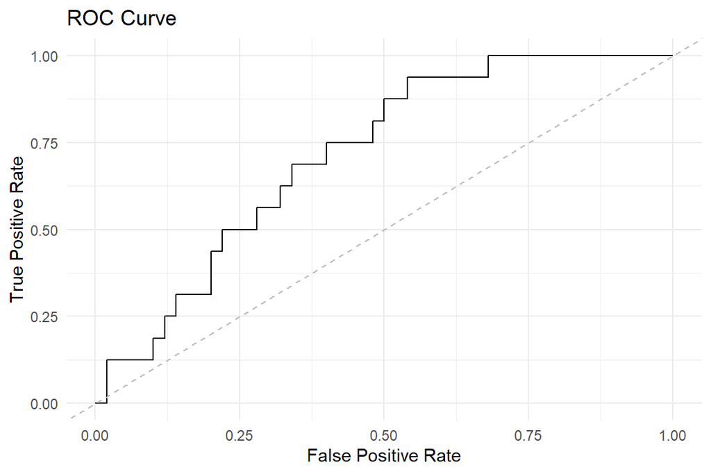

```r
pred <- summary_df$Pred
obs <- summary_df$Obs

# Create a prediction object
prediction <- prediction(pred, obs)

# Create a performance object to calculate ROC and AUC
performance <- performance(prediction, "tpr", "fpr")

# Extract ROC data
roc_data <- data.frame(
  FPR = performance@x.values[[1]],
  TPR = performance@y.values[[1]]
)

# Plot ROC curve using ggplot2
ggplot(roc_data, aes(x = FPR, y = TPR)) +
  geom_line() +
  geom_abline(slope = 1, intercept = 0, linetype = "dashed", color = "gray") +
  labs(title = "ROC Curve", x = "False Positive Rate", y = "True Positive Rate") +
  theme_minimal()
```

```r
# Calculate AUC
auc <- performance(prediction, "auc")
cat("AUC:", auc@y.values[[1]])
```

```
## AUC: 0.715
```

```r
# Sensitivity / Specificity curve

perf <- performance(prediction, "sens", "spec")
perf
```

```
## A performance instance
##   'Specificity' vs. 'Sensitivity' (alpha: 'Cutoff')
##   with 66 data points
```

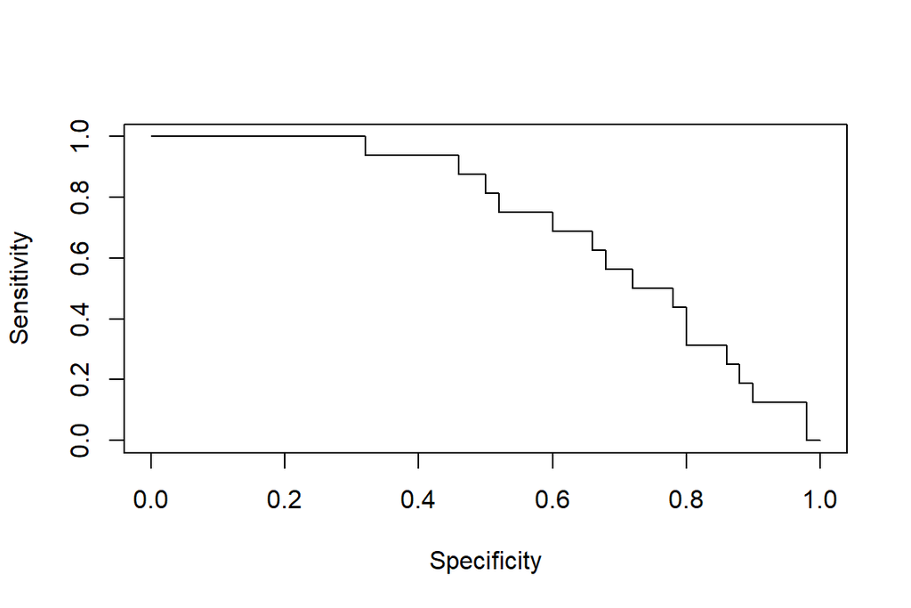

```r
plot(perf)
```

```r
# precision / recall curve

perf <- performance(prediction, "prec", "rec")

perf
```

```
## A performance instance
##   'Recall' vs. 'Precision' (alpha: 'Cutoff')
##   with 66 data points
```

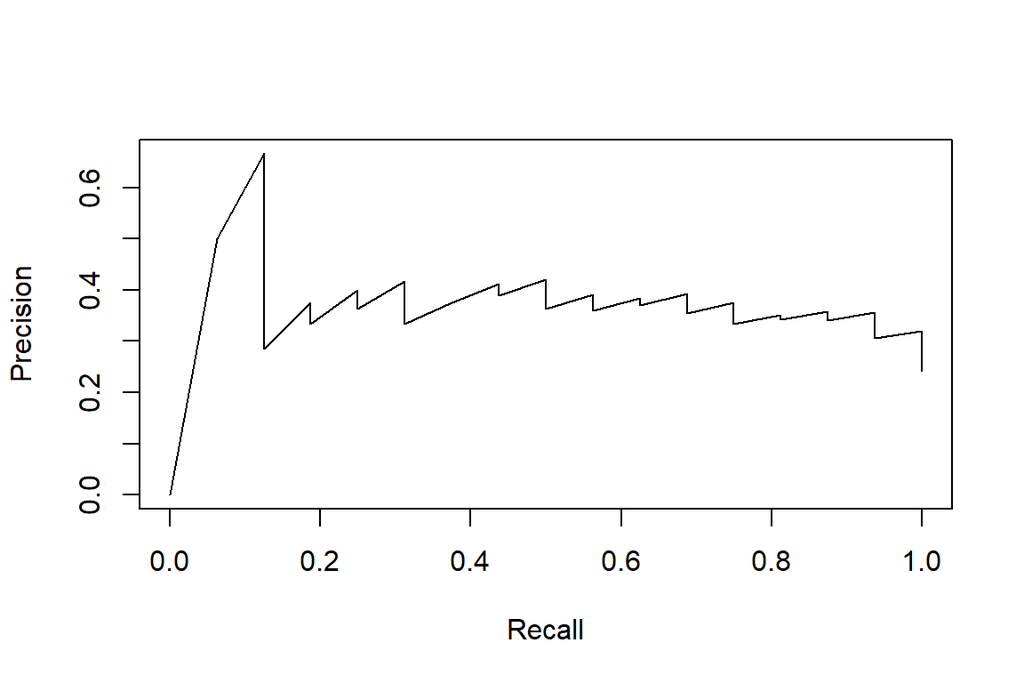

```r
plot(perf
     )
```

# 12 Some other evaluation metrics and confusion matrix

Since the outcome variable of infection status is binary (infected or not infected), we transformed the estimated probability values into discrete classifications for analysis. Infection probabilities ranging from 0 to 0.5 were designated as class 0 (uninfected) while probabilities from 0.5 to 1 were assigned as class 1 (infected). This divides the probability continuum at the 0.5 threshold to categorize the predictions.

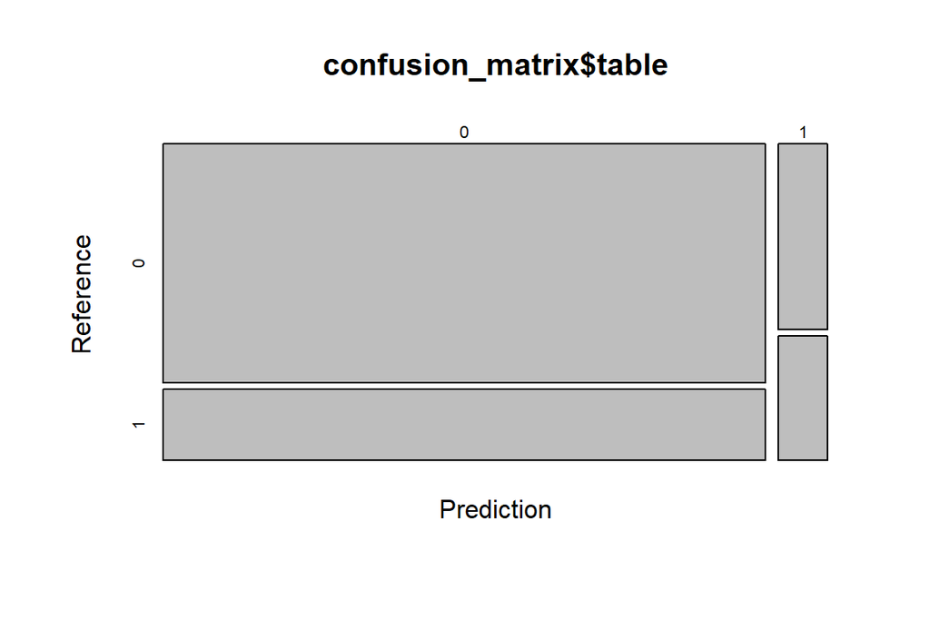

```r
threshold <- 0.5
predicted_class <- ifelse(pred >= threshold, 1, 0)

predicted_class <- factor(predicted_class, levels = c(0, 1))
obs <- factor(obs, levels = c(0, 1))

# Create a confusion matrix
confusion_matrix <- confusionMatrix(predicted_class, obs)

plot(confusion_matrix$table,
     colorRampPalette(colors = c("darkblue","grey","orange"))(100))
```

```r
# Print the confusion matrix
print(confusion_matrix)
```

```
## Confusion Matrix and Statistics
##
##           Reference
## Prediction  0  1
##          0 47 14
##          1  3  2
##
##                Accuracy : 0.7424
##                  95% CI : (0.6199, 0.8422)
##     No Information Rate : 0.7576
##     P-Value [Acc > NIR] : 0.67384
##
##                   Kappa : 0.0848
##
##  Mcnemar's Test P-Value : 0.01529
##
##             Sensitivity : 0.9400
##             Specificity : 0.1250
##          Pos Pred Value : 0.7705
##          Neg Pred Value : 0.4000
##              Prevalence : 0.7576
##          Detection Rate : 0.7121
##    Detection Prevalence : 0.9242
##       Balanced Accuracy : 0.5325
##
##        'Positive' Class : 0
##
```